# 統計データ解析I

## 少数の法則

### 問題

少数の法則の数値実験を行いなさい．

- 1日の総生産量 $n$ が 5000， 不良品の発生確率 $p$ が 0.002 である工場を例として， 2年間の操業 (週5日x100週間) において観測される不良品数の分布を確認しなさい．
- 母数 $n,p$ の違いによって結果がどのように変わるか観察しなさい．

### 解答例

以下，日本語を用いるため macOS では以下の設定を行う．

```r
if(Sys.info()["sysname"] == "Darwin") { # macOS か調べて日本語フォントを指定
    theme_update(text = element_text(family = "HiraginoSans-W4"))
    update_geom_defaults("text", list(family = theme_get()$text$family))
    update_geom_defaults("label", list(family = theme_get()$text$family))
}
```

基本の実験を行う

```r
n <- 5000    # 1日の総生産量
p <- 0.002   # 不良品の発生確率
N <- 5*50*2  # 観測日数(週5日x50週間x2年操業に対応)
x <- rbinom(N,n,p) # 不良品数
#' x <- replicate(N, rbinom(1,n,p)) # 同上 (書き方はいろいろある)
(my_data <- table(x)) # 不良品数の度数分布表を作成
```

```
x
 3  4  5  6  7  8  9 10 11 12 13 14 15 16 17 18 19
 5 10 22 31 35 65 68 54 59 48 36 23 17 13 10  2  2
```

それぞれの不良品数が生じた日数の割合のグラフを作成する．

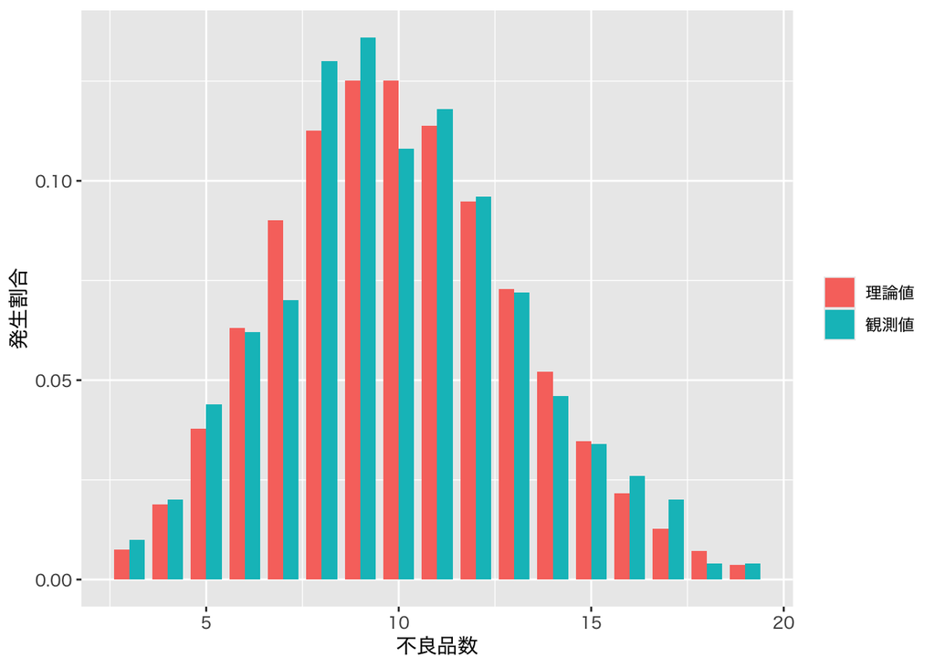

```r
tibble(不良品数 = as.numeric(names(my_data)),
       観測値 = as.numeric(my_data/N),
       理論値 = dpois(不良品数, n*p)) |>
    pivot_longer(!不良品数, values_to = "発生割合") |>
    ggplot(aes(x = 不良品数, y = 発生割合, fill = name)) +
    geom_bar(stat = "identity",
             width = 0.8, # 並びがわかりやすいように幅を調整
             position = "dodge") +
    labs(fill = NULL) # 凡例のfillの名称(name)を消去
```

`n` の違いを比較する．

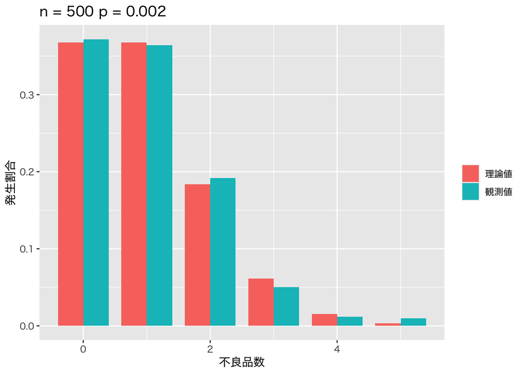

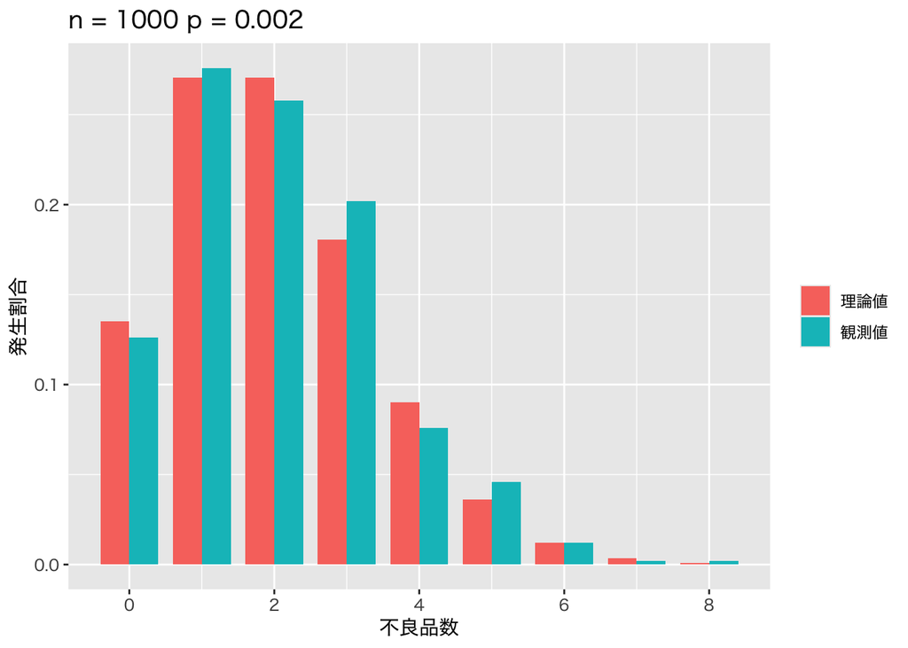

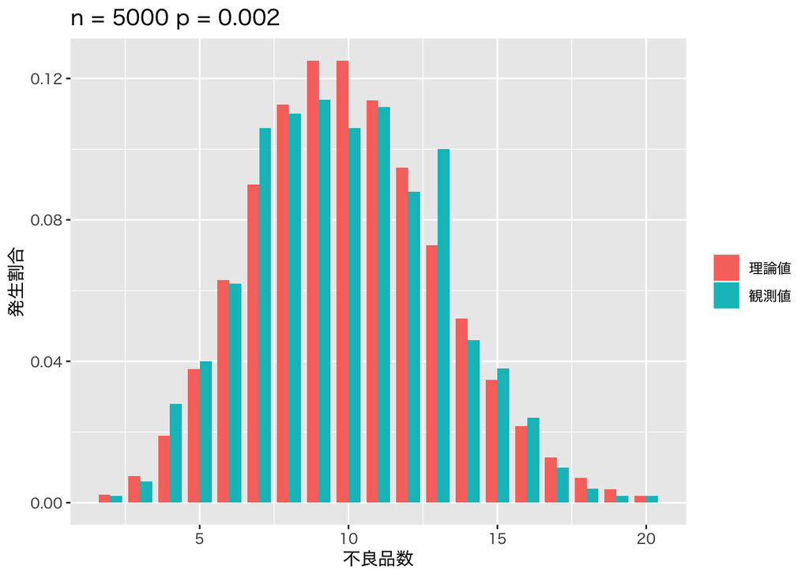

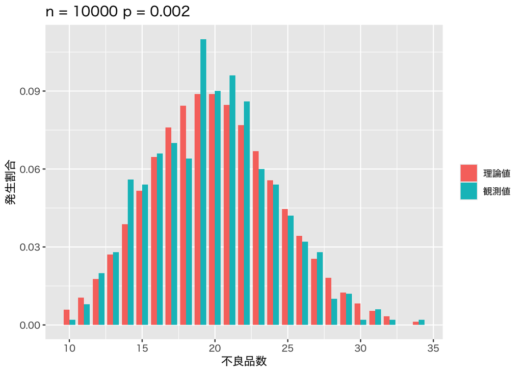

```r
p <- 0.002
for(n in c(500,1000,5000,10000)){
    x <- rbinom(N,n,p)
    my_data <- table(x)
    foo <- tibble(不良品数 = as.numeric(names(my_data)),
                  観測値 = as.numeric(my_data/N),
                  理論値 = dpois(不良品数, n*p)) |>
        pivot_longer(!不良品数, values_to = "発生割合") |>
        ggplot(aes(x = 不良品数, y = 発生割合, fill = name)) +
        geom_bar(stat = "identity",
                 width = 0.8,
                 position = "dodge") +
        labs(fill = NULL,
             title = paste("n =", n, "p =", p))
    print(foo)
}
```

`p` の違いを比較する．

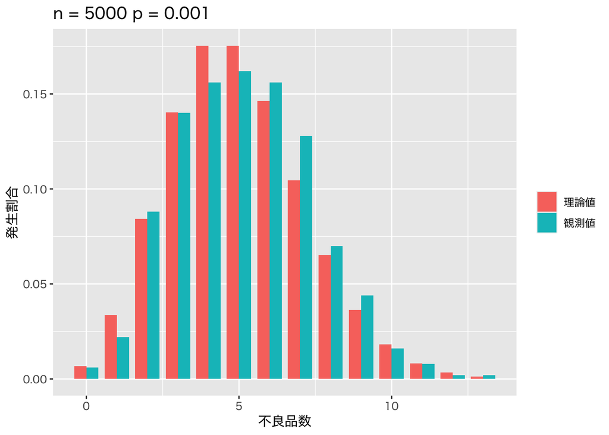

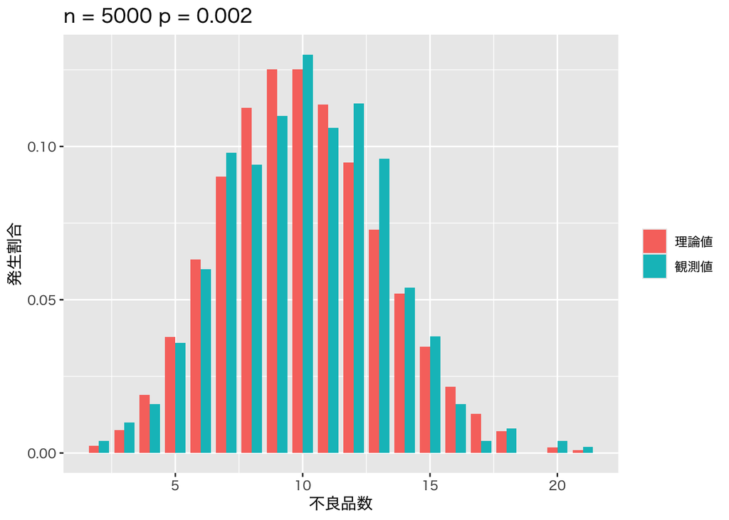

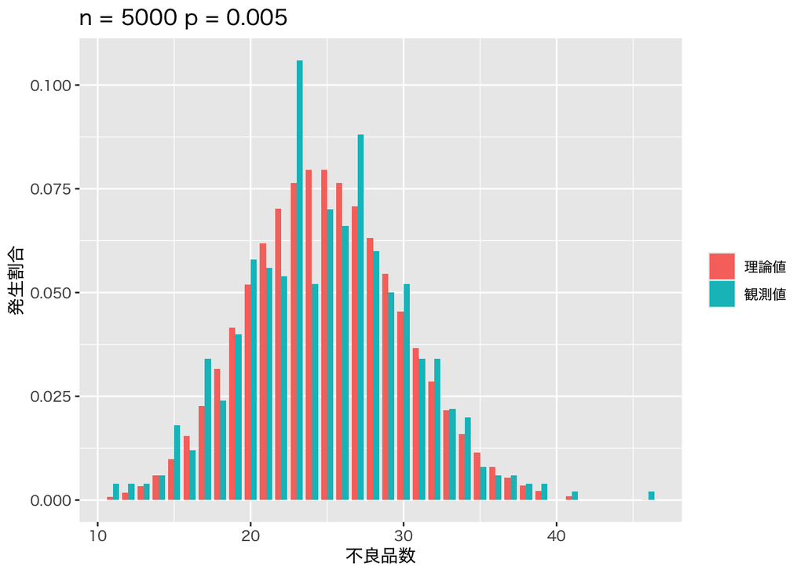

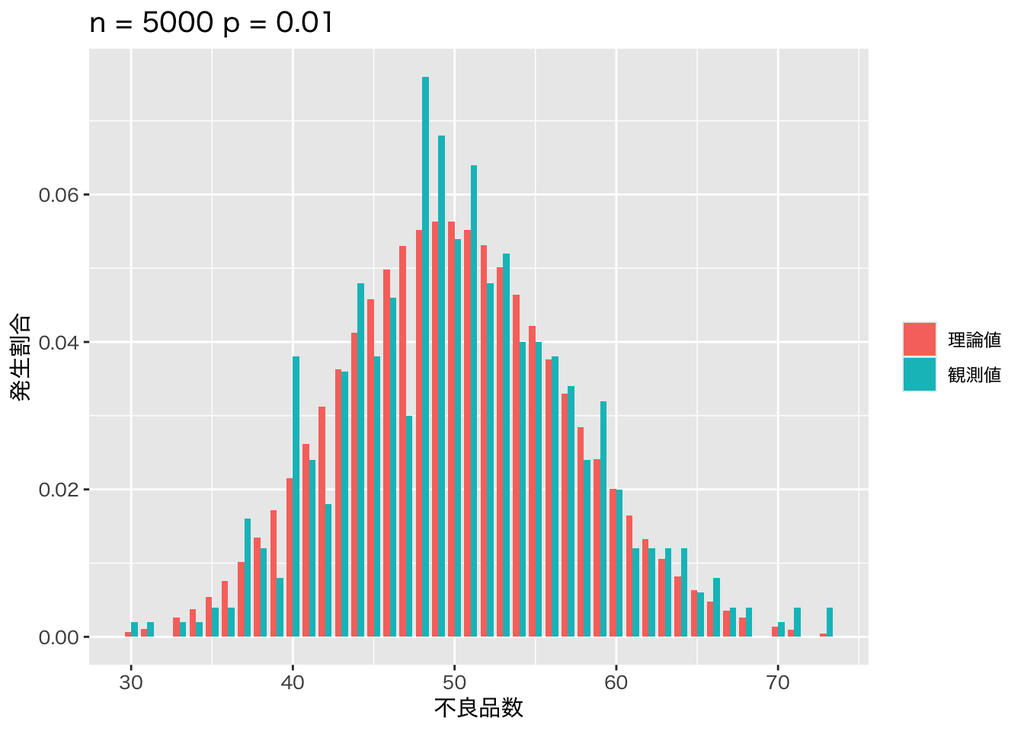

```r
n <- 5000
for(p in c(0.001,0.002,0.005,0.01)){
    x <- rbinom(N,n,p)
    my_data <- table(x)
    foo <- tibble(不良品数 = as.numeric(names(my_data)),
                  観測値 = as.numeric(my_data/N),
                  理論値 = dpois(不良品数, n*p)) |>
        pivot_longer(!不良品数, values_to = "発生割合") |>
        ggplot(aes(x = 不良品数, y = 発生割合, fill = name)) +
        geom_bar(stat = "identity",
                 width = 0.8,
                 position = "dodge") +
        labs(fill = NULL,
             title = paste("n =", n, "p =", p))
    print(foo)
}
```

**Note**

`n` が大きくなるに従い，正規分布の形に近付いていくことが観測できる． 中心極限定理がここでも成り立っていることがわかる．